# Troudt_A5_ISQA_8080

Eric Troudt

December 17, 2019

## PART 1

**a.** Global functions will fit the entire set of observations,and therefore that single function will be used for predicting all values of yi (from i to n). In contrast, step functions can provide separate fits for each of the corresponding segments (bins) of any given set of observations, which can be highly flexible with less variance when compared with a global function that fits at that same level of flexibility.

**b.** Regression splines are regression-based fits of the individual segments (the textbook describes cubic splines, which appear to be the most common) that are smoothed at each of the knots by imposing additional constraints of continuity at the 1st and 2nd order derivatives (for cubic). The number of knots and their corresponding placements within the range of X allow for more flexible fits of areas in the dataset that are more variable. Conversely, smoothing splines are forms of natural splines in which each individual observation is a knot. To prevent the extreme over-fitting of the data that would otherwise result from using knots at each observation, smoothing splines are constrained by an additional penalty term imposed on its measure of overall smoothness, which effectively shrinks the coefficient estimates based on the value of the penalty function’s tuning parameter. This ‘shrinking’ of the coefficient estimates to account for the bias-variance trade-off is what makes smoothing splines conceptually similar to the Ridge and LASSO regression approaches.

**c.** The scatterplot of the dataset below shows that the relationship between x and y is clearly non-linear from a global perspective. If the data are binned into 3 equal segments, then the 1st and 3rd bins are linear while the middle bin is not.

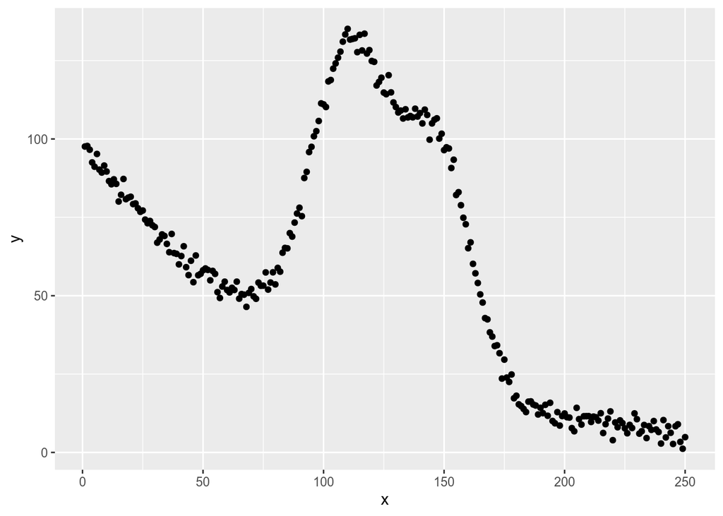

### *Linear Model*

**d.** Based on the results of the linear model on the test below, the amount of variability captured by the linear model is not very high (~ 36%), and indicates what we can clearly see from plotting the dataset, namely that there is a nonlinear relationship that cannot be efficiently captured with simple linear regression.

```
##
## Call:
## lm(formula = .outcome ~ ., data = dat)
##
## Residuals:
##    Min     1Q Median     3Q    Max
## -32.10 -23.43 -16.13  27.44  69.07
##
## Coefficients:
##              Estimate Std. Error t value Pr(>|t|)
## (Intercept) 101.25469    4.92176   20.57   <2e-16 ***
## x            -0.32271    0.03386   -9.53   <2e-16 ***
## ---
## Signif. codes:  0 '***' 0.001 '**' 0.01 '*' 0.05 '.' 0.1 ' ' 1
##
## Residual standard error: 32.31 on 176 degrees of freedom
## Multiple R-squared:  0.3404, Adjusted R-squared:  0.3367
## F-statistic: 90.83 on 1 and 176 DF,  p-value: < 2.2e-16
```

```
##       RMSE   Rsquared        MAE
## 32.4895769  0.3829068 28.3282712
```

### *Polynomial Regression Model*

**e.** Based on the results of the polynomial regression model on the training/test below, the amount of variability captured by the polynomial model is much higher (~ 85%), and the RMSE is about half of what is was with the linear model.

[output not shown]

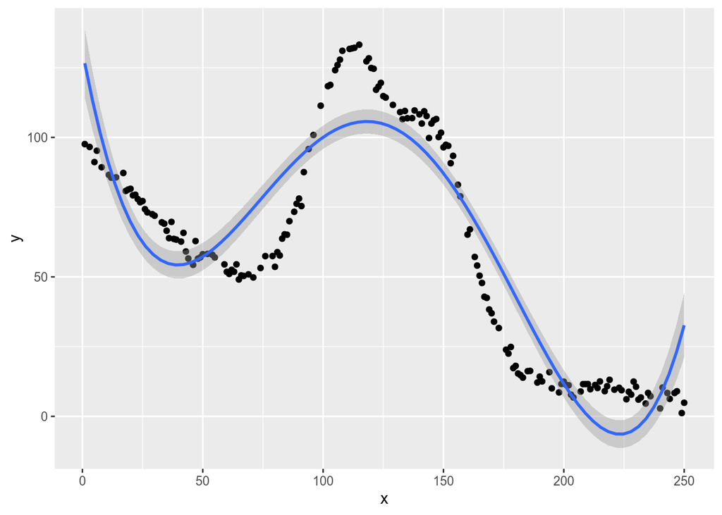

```
##       RMSE   Rsquared        MAE
## 15.4539440  0.8619913 12.8465213
```

### *Natural Spline Model*

**f.** Based on the results of the natural spline model on the training/test below, the amount of variability captured by the natural spline model is almost perfect (99%), and the RMSE is about 1/5 of what is was with the polynomial regression model.

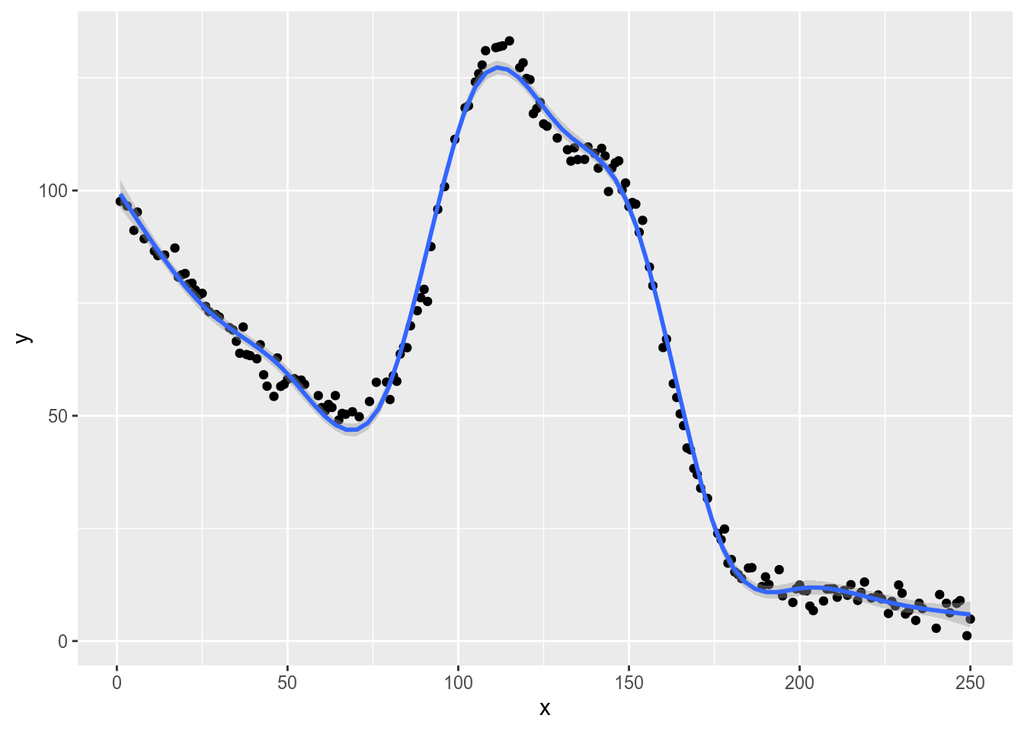

```
##     RMSE Rsquared      MAE
## 3.241572 0.993920 2.609982
```

### *Local Regression Model*

```
## [1] "RMSE for local regression with span 0.2"
```

```
##      RMSE  Rsquared       MAE
## 2.6942008 0.9959366 2.1823302
```

```
## [1] "RMSE for local regression with span 0.5"
```

```
##      RMSE  Rsquared       MAE
## 6.9450758 0.9720792 5.5366180
```

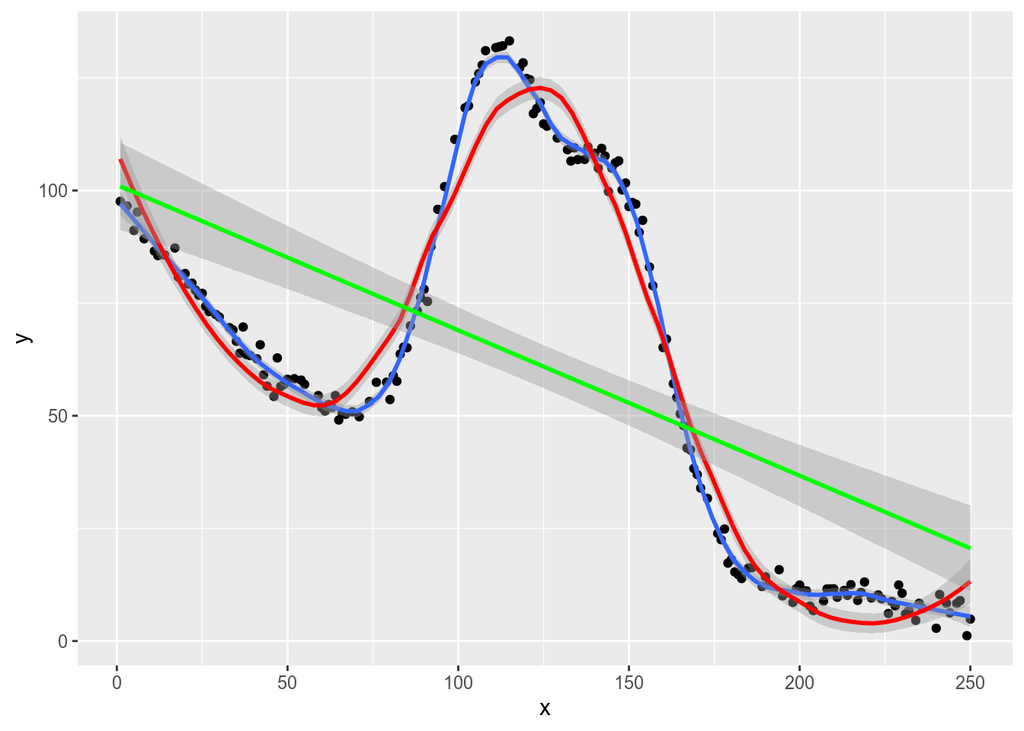

## PART 2 Clustering 1

**a.** Initial Cluster Assignments

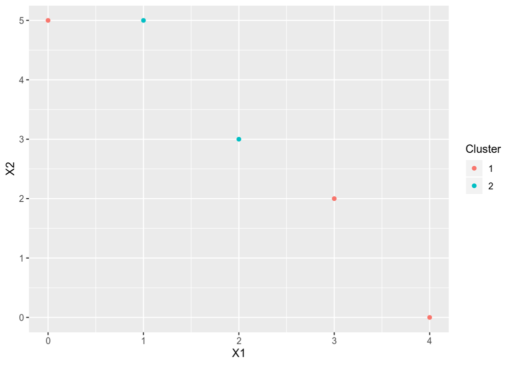

**b.** Initial Cluster Centroids

```
## [1] "Cluster 1 centroid: X1 = 2.33333, X2=2.33333"
```

```
## [1] "Cluster 2 centroid: X1 = 1.5, X2=4"
```

**c.** New Cluster Assignments

```
## [1] "New Cluster Values for iteration: 1"
## [1] 2 2 1 1 1
## [1] "New Cluster Values for iteration: 2"
## [1] 2 2 1 1 1
```

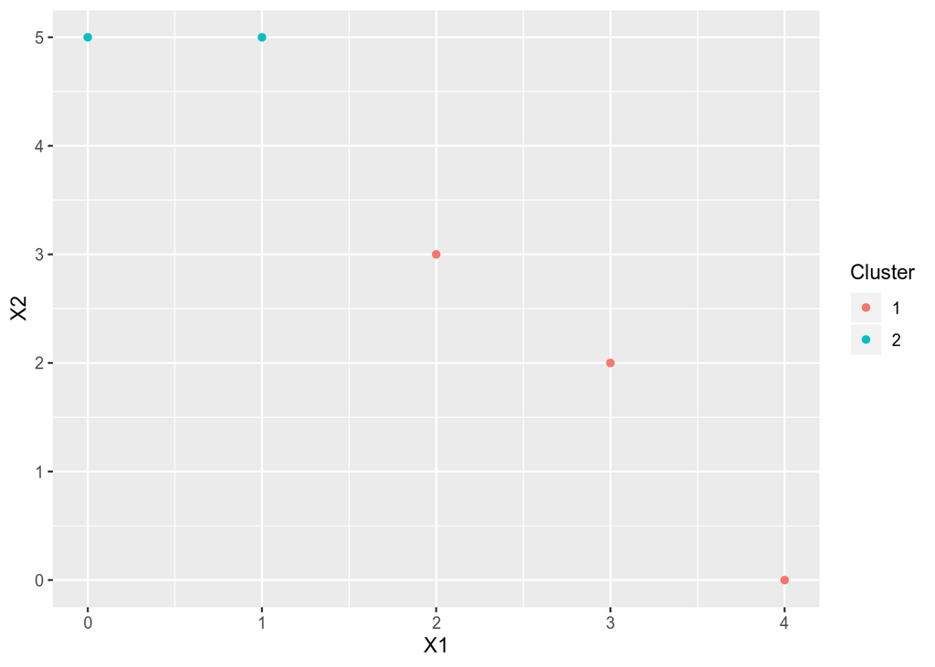

## PART 2 Clustering 2

**a** Based off the scree plot below, the elbow seems to occur around 5, after which the additional within-cluster variation contributed by more clusters is not significant.

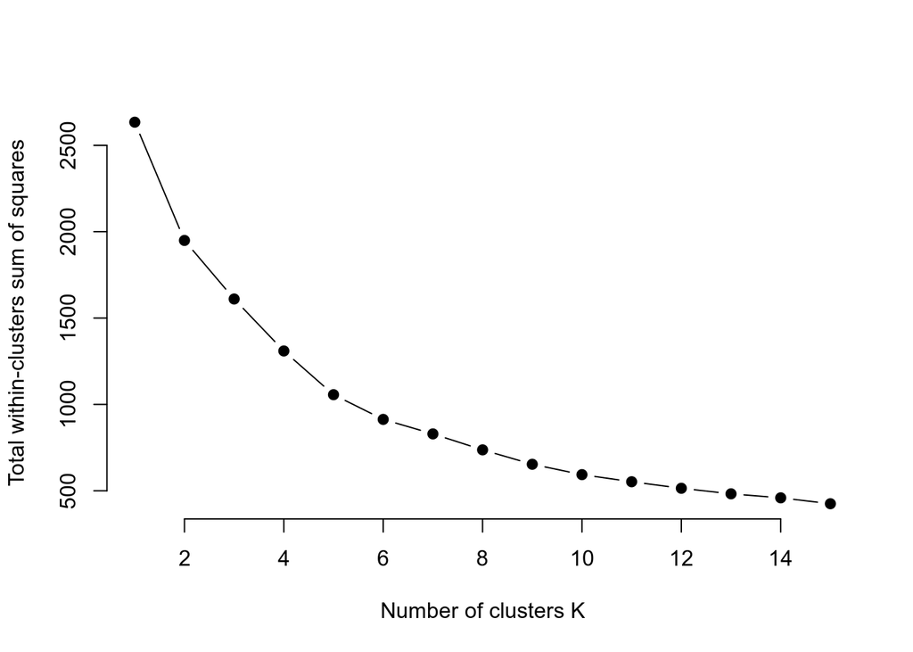

**b.** Based off the ggpairs plot below, strong clusters are observed for many of the pairwise comparisons between of Fresh products and Detergents/Paper (Detergents_Paper vs Frozen, Fresh vs Grocery, etc.). Cluster 3 appears to be over-represented in region A, which may also indicate particular spending preferences for types of product based on region.

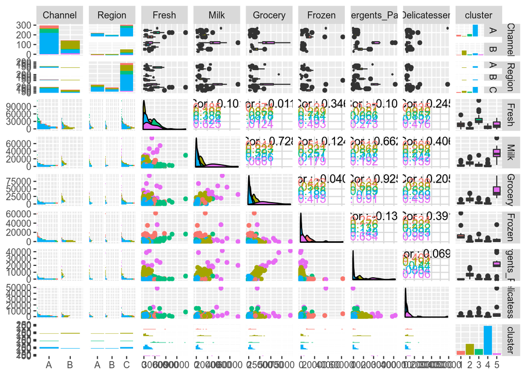

**c.** Based on the summary of the clusters for the two different linkage methods, single linkage is less balanced, with single observations comprising 4 out of the 5 clusters, which is consistent with the drawback of single linkage described in the textbook.

```
##      Fresh              Milk            Grocery            Frozen
##  Min.   :-0.9486   Min.   :-0.7779   Min.   :-0.8364   Min.   :-0.62763
##  1st Qu.:-0.7015   1st Qu.:-0.5776   1st Qu.:-0.6101   1st Qu.:-0.47988
##  Median :-0.2764   Median :-0.2939   Median :-0.3363   Median :-0.31844
##  Mean   : 0.0000   Mean   : 0.0000   Mean   : 0.0000   Mean   : 0.00000
##  3rd Qu.: 0.3901   3rd Qu.: 0.1889   3rd Qu.: 0.2846   3rd Qu.: 0.09935
##  Max.   : 7.9187   Max.   : 9.1732   Max.   : 8.9264   Max.   :11.90545
##  Detergents_Paper   Delicatessen     factor(cluster_complete)
##  Min.   :-0.6037   Min.   :-0.5396   1:426
##  1st Qu.:-0.5505   1st Qu.:-0.3960   2: 10
##  Median :-0.4331   Median :-0.1984   3:  2
##  Mean   : 0.0000   Mean   : 0.0000   4:  1
##  3rd Qu.: 0.2182   3rd Qu.: 0.1047   5:  1
##  Max.   : 7.9586   Max.   :16.4597
##  factor(cluster_single)
##  1:436
##  2:  1
##  3:  1
##  4:  1
##  5:  1
##
```

**d.** Based on the summary of the clusters below for the two different linkage methods, single linkage is still not balanced, with single observations comprising 3 out of the 5 clusters (another cluster only consisted of two observations). The complete linkage method benefitted much more from outlier removal, displaying greater balance among its 5 clusters.

```
##      Fresh              Milk            Grocery            Frozen
##  Min.   :-1.0401   Min.   :-1.0169   Min.   :-1.0246   Min.   :-0.8340
##  1st Qu.:-0.7520   1st Qu.:-0.7244   1st Qu.:-0.7149   1st Qu.:-0.6193
##  Median :-0.2856   Median :-0.2973   Median :-0.3554   Median :-0.3813
##  Mean   : 0.0000   Mean   : 0.0000   Mean   : 0.0000   Mean   : 0.0000
##  3rd Qu.: 0.4738   3rd Qu.: 0.3938   3rd Qu.: 0.4039   3rd Qu.: 0.2063
##  Max.   : 4.2150   Max.   : 5.0615   Max.   : 4.2950   Max.   : 5.0035
##  Detergents_Paper   Delicatessen     factor(cluster_NoOutliers_complete)
##  Min.   :-0.7128   Min.   :-1.0202   1: 17
##  1st Qu.:-0.6404   1st Qu.:-0.6996   2: 15
##  Median :-0.4879   Median :-0.2850   3: 73
##  Mean   : 0.0000   Mean   : 0.0000   4: 42
##  3rd Qu.: 0.3588   3rd Qu.: 0.3809   5:277
##  Max.   : 4.7029   Max.   : 5.2801
##  factor(cluster_NoOutliers_single)
##  1:419
##  2:  2
##  3:  1
##  4:  1
##  5:  1
##
```